# Analyzing the NYC Subway Dataset

## Introduction to Data Science, Udacity

## References

For the preparation of this report, I made use of the following:

[1]: http://pandas.pydata.org/pandas-docs/stable/ **pandas** documentation

[2]: http://matplotlib.org/contents.html **matplotlib** documentation

[3]: http://statsmodels.sourceforge.net/stable/index.html **statsmodels** documentation

I consulted stackoverflow and wikipedia, noteworthily the following:

[4]: https://en.wikipedia.org/wiki/Mann%E2%80%93Whitney_U_test Mann Whitney U test

[5]: https://en.wikipedia.org/wiki/New_York_City_Subway The New York City Subway

[6]: http://stackoverflow.com/a/9768339/2757226 Histogram with Relative Frequencies

[7]: http://everythingyouforgetaboutlatex.blogspot.ca/2008/11/another-quick-post-this-time-about-math.html Everything You Forgot About LaTeX

And I reviewed some concepts of statistic in the book:

Rowntree, Derek (2004) *Statistics Without Tears - A Primer for Non-Mathematicians*

## 1. Statistical Test

### 1.1 Statistical test used to analyze the NYC subway data.

To figure out if more people ride the subway when it is raining versus when it is not raining, I separated the data into two groups: **`rain`** and **`norain`**, and performed the Mann–Whitney U test:

Denoting the **`ENTRIESn_hourly`** variable, as E:

$$E = ENTRIESn\_hourly$$

The null hypothesis is that there is no difference in ridership. The observed differences between means is due to chance:

$$H_0: \overline{E_{rain}} = \overline{E_{norain}}$$

The alternative hypothesis is that there is a real difference between both means. Either group can have a larger mean and the difference between them can't be explained by chance only.

$$H_A: \overline{E_{rain}} \neq \overline{E_{norain}}$$

I need to determine with 95% confidence if less or more people ride the subway when it is raining versus when it is not raining. For this reason:

$$p-critical = 0.05,\ two\ tails$$

```python
import pandas as pd
import numpy as np

tw = pd.read_csv('turnstile_weather_v2.csv')
norain, rain = (tw[tw['rain']==_]['ENTRIESn_hourly'] for _ in (0,1))

print("There is in average {:.1f} more ENTRIESn_hourly when it rains, but is this difference significant?"\
      .format( rain.mean() - norain.mean() ))
```

```
There is in average 182.7 more ENTRIESn_hourly when it rains, but is this difference significant?
```

### 1.2 Applicability of the test to the dataset.

The Mann Whitney U test is applicable to the dataset because it adheres to the test assumptions, in particular the following:

- The two groups under consideration are random and independent of each other, as well as the observations within each group.
- The observations are numeric and can be arranged in ranks (i.e. one can say of two observations which is greater).
- This dataset has a non-normal, highly skewed distribution (Fig 3.1). Most of the observations are in the lower end (0-6000), and it has a big tail with a maximum value of 32814 entries. For this reason the applicability of the t-test is questionable.
- When separating the dataset in two groups, **`rain`** and **`norain`**, the distribution of both groups is very similar (Fig. 3.2). Judging just by the relative frequencies of both groups, it is not possible to tell any difference in ridership.

```python
print("The maximum value observed is: {:.0f} ENTRIESn_hourly".format(tw['ENTRIESn_hourly'].max()))
```

```
The maximum value observed is: 32814 ENTRIESn_hourly
```

### 1.3 Results of the test

The two groups **rain** and **norain** were compared using the Mann–Whitney two-sample rank-sum test, obtaining the following results:

```python
import scipy.stats
U, p = scipy.stats.mannwhitneyu(rain, norain)
rain.mean(), norain.mean(), U, p
```

```
(2028.1960354720918, 1845.5394386644084, 153635120.5, 2.7410695712437496e-06)
```

$\overline{E_{rain}} = 2028.2$

$\overline{E_{norain}} = 1845.5$

$\Delta\overline{E} = 182.7$

$U = 153635120.5$

$2\cdot p < .001$

$2\cdot p < p-critical$

### 1.4 Significance and interpretation of the results

With these results, I can reject the null hypothesis with a 95% confidence in favor of the alternative hypothesis: the differences observed between the two groups cannot be explained just by chance. There is a real difference between both distributions.

## 2. Linear Regression

### 2.1 Method used

To compute the linear regression coefficients, I used the Ordinary Least Squares, OLS method from the statsmodels package.

```python
import statsmodels.api as sm
```

### 2.2 Variables selected for the model

The values, or dependent variable, is ENTRIESn_hourly

```python
y = tw['ENTRIESn_hourly']
```

For the model I used the following features, or independent variables:

- hour
- weekday
- rain
- tempi
- wspdi

Besides these variables, I used the following dummy variable:

- station

And I added a constant to the model.

```python
X = tw[['hour', 'weekday', 'rain', 'tempi', 'wspdi']]
dummies = pd.get_dummies(tw[['station']])
X = X.join(dummies)
X1 = sm.add_constant(X)
```

### 2.3 Reasons to select each variable used

I started by computing the individual $r^2$ for each variable that I deemed could contribute to explain the difference in ridership, and obtained the following:

| variable | UNIT | station | hour | weekday | conds | day_week |
| --- | --- | --- | --- | --- | --- | --- |
| **$$r^2$$** | 0.37522 | 0.32426 | 0.08225 | 0.02115 | 0.00976 | 0.00901 |

| variable | tempi | wspdi | meanwspdi | meanprecipi | pressurei | precipi | meantempi | rain | fog | meanpressurei |
| --- | --- | --- | --- | --- | --- | --- | --- | --- | --- | --- |
| **$$r^2$$** | 0.00803 | 0.00314 | 0.00158 | 0.00127 | 0.00111 | 0.00077 | 0.00071 | 0.00067 | 0.00007 | 0.00004 |

### 2.4 Equation: Intercept and Coefficients

The parameters obtained from the linear regression model are:

```python
model = sm.OLS(y, X1)
results = model.fit().params
a, B = results[0], results[1:]
print('intercept, a = {}'.format(a))
```

```
intercept, a = -441.372979939
```

```python
print('coefficients, B\n---------------\n{}'.format(B))
```

```
coefficients, B
---------------
hour                       121.370056
weekday                    966.940504
rain                        50.658249
tempi                        3.652826
wspdi                        4.112299
station_1 AVE             1446.189007
station_103 ST-CORONA      856.854101
station_104 ST           -1379.087543
station_110 ST             121.075717
station_110 ST-CPN        -373.468866
station_111 ST            -852.370310
station_121 ST           -1422.203308
station_125 ST             796.969797
station_135 ST             341.504676
station_138 ST-GR CONC   -1286.174408
...
station_SUTPHIN BLVD       1496.175142
station_SUTTER AVE         -494.475786
station_UNION ST           -673.976635
station_VAN SICLEN AVE    -1191.063351
station_VAN WYCK BLVD      -887.249634
station_VERNON/JACKSON     -254.211986
station_W 8 ST-AQUARIUM   -1330.583566
station_WALL ST            1219.129411
station_WASHINGTON-36 A    -545.006982
station_WESTCHESTER SQ    -1130.805826
station_WHITLOCK AVE      -1316.970208
station_WILSON AVE        -1071.695421
station_WOODHAVEN BLVD    -1092.607421
station_WOODLAWN ROAD      -456.745921
station_WORLD TRADE CTR    5521.546078
Length: 212, dtype: float64
```

### 2.5 Coefficient of determination, $R^2$ value

```python
y_hat = a + np.dot(X, B)
r2 = 1 - ((y-y_hat)**2).sum()/((y-np.mean(y))**2).sum()
print("The coefficient of determination, R^2 = {:.5f}".format(r2))
```

```
The coefficient of determination, R^2 = 0.43029
```

The coefficient of determination obtained with this model is $R^2 = 0.43029$

### 2.6 Goodness of fit for the regression model

To try to determine how well the model fits the data, or how well it will predict a future set of observations so as to be considered useful, I will examine the coefficient of determination and the residuals.

#### $R^2$

The coefficient of determination, $R^2 = 0.43029$ is an indicator of the stregth of the relationship between the variables. It means that $43.0\%$ of the variations observed in **ENTRIESn_hourly** can be explained due to the variation in the regressor variables chosen: **hour, weekday, rain, tempi, wspdi, station**. The other $57.0\%$ is due to the influence of other variables, by randomness, or by the model chosen (in this case a linear model). $R^2$ can be considered as related to the unexplained variance of the model.

#### *Residuals*

The residuals —the difference between the observed data and the predicted values— are a measure of the model's errors. To examine these residuals I drew a histogram (Fig 2.1), a plot (Fig 2.2) of residuals and a quantiles-quantiles plot (Fig 2.3)

From these graphs I observe the following:

- The histogram of the residuals has long asymmetrical tails. The tail in the positive side is much longer than the negative tail.
- The distribution of the residuals is not "normal". I is positively skewed and has extreme values.
- The plot hints some periodic or cyclic pattern, which is not very clear or easy to identify.
- The Q-Q plot shows three regions: a central region with closer fit, and two outer regions where the distribution of residuals departs significantly from a normal distribution.

#### *Conclusion*

Considering the results obtained in the linear regression analysis —the value of $R^2$ and the graphs of the residuals— I conclude that the linear model is not appropriate for the regression analysis of this dataset. The model fits the data only in one portion of the data, but not for the whole dataset. The model predicts values that tend to be larger than the observed ones.

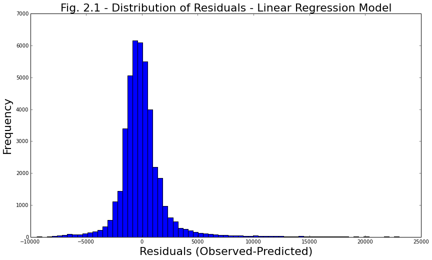

```python
import matplotlib.pyplot as plt
%matplotlib inline
fontsize = 18

fig, axes = plt.subplots(nrows=1, ncols=1, figsize=(14,8))

axes.hist(y - y_hat, bins=75)
axes.set_title('Fig. 2.1 - Distribution of Residuals - Linear Regression Model', fontsize=fontsize+4)
axes.set_xlabel('Residuals (Observed-Predicted)', fontsize=fontsize+4)
axes.set_ylabel('Frequency', fontsize=fontsize+4)

plt.show()
```

Fig. 2.1 Shows the distribution of the linear regression analysis' residuals. The main portion of the distribution shows traits of normality with some positive skew. However, the tails contain very large residuals. In any case, the values of the residuals are too big for the model to be considered appropriate of "close enough" to be useful.

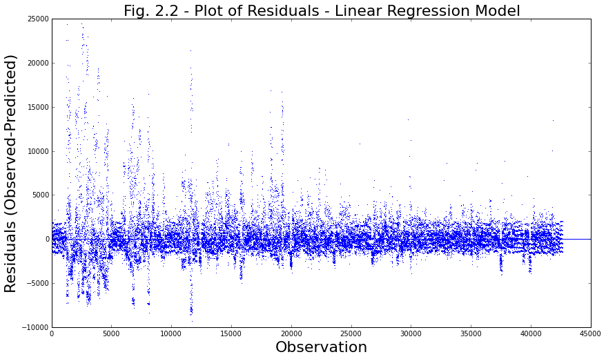

```python
fig, axes = plt.subplots(nrows=1, ncols=1, figsize=(14,8))

axes.plot(y - y_hat, 'b,')
axes.plot([0,45000], [0,0])

axes.set_title('Fig. 2.2 - Plot of Residuals - Linear Regression Model', fontsize=fontsize+4)
axes.set_ylabel('Residuals (Observed-Predicted)', fontsize=fontsize+4)
axes.set_xlabel('Observation', fontsize=fontsize+4)

plt.show()
```

Fig. 2.2 Plotting the residuals for each observation reveals some sort of pattern in the extreme residuals.

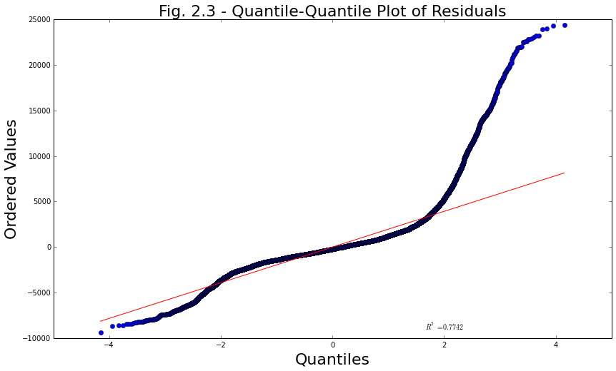

```python
import statsmodels
fig, axes = plt.subplots(nrows=1, ncols=1, figsize=(14,8))

scipy.stats.probplot(y - y_hat, plot=axes)

axes.set_title('Fig. 2.3 - Quantile-Quantile Plot of Residuals', fontsize=fontsize+4)
axes.set_ylabel('Ordered Values', fontsize=fontsize+4)
axes.set_xlabel('Quantiles', fontsize=fontsize+4)

plt.show()
```

Fig. 2.3 Ordering the residuals and plotting them together with the corresponding value of a normal distribution (red line) shows how close or far from normal is the model's response.

### 2.7 Example of Predictions using the Model

The formula for the model, to make predictions, is:

$\hat{y} = a + B \cdot x$

$\begin{eqnarray*}\ Where: &\ & a & = & intercept\ & B & = & coefficients\ & x & = & values\ for\ each\ of\ the\ regressor\ variables\ & \hat{y} & = & predicted\ ENTRIESn_hourly\ \end{eqnarray*}$

```python
from collections import OrderedDict as OD

def predict(hour, weekday, rain, tempi, wspdi, station):
    x_dummies = OD(zip(dummies.columns, [0]*len(dummies)))
    if 'station_'+station not in x_dummies:
        print('station "{}" not recognized in the model'.format(station))
        return
    x_dummies['station_'+station] = 1
    x = [hour, weekday, rain, tempi, wspdi]
    x.extend(x_dummies.values())
    y_hat = a + np.dot(B,x)
    return y_hat
```

```python
st = '111 ST'
header = ('hour','weekday', 'rain',  'tempi', 'wspdi', 'station' )
rainy = [   (20,     1,       1,        53,     10,        st ),
            (20,     1,       1,        53,     15,        st ),
            (20,     1,       1,        58,     10,        st ),
            (20,     1,       1,        58,     15,        st ),
            (20,     1,       1,        63,     10,        st ),
            (20,     1,       1,        63,     15,        st  )]


predicted = []
print("Rainy conditions")
for x in rainy:
    xs = OD(zip(header, x))
    prediction = predict(**xs)
    predicted.append(prediction)
    xs['entries'] = prediction
    print("hour={}, weekday={}, rain={}, tempi={}, wspdi={}, station='{}',   entries={:.0f}"\
         .format(*xs.values()))

not_rainy = [
            (20,     1,       0,        53,     10,        st ),
            (20,     1,       0,        53,     15,        st ),
            (20,     1,       0,        58,     10,        st ),
            (20,     1,       0,        58,     15,        st ),
            (20,     1,       0,        63,     10,        st ),
            (20,     1,       0,        63,     15,        st  )]

print
print("Not Rainy conditions")
for x in not_rainy:
    xs = OD(zip(header, x))
    prediction = predict(**xs)
    xs['entries'] = prediction
    print("hour={}, weekday={}, rain={}, tempi={}, wspdi={}, station='{}',   entries={:.0f}"\
         .format(*xs.values()))
```

```
Rainy conditions
hour=20, weekday=1, rain=1, tempi=53, wspdi=10, station='111 ST',   entries=2386
hour=20, weekday=1, rain=1, tempi=53, wspdi=15, station='111 ST',   entries=2407
hour=20, weekday=1, rain=1, tempi=58, wspdi=10, station='111 ST',   entries=2404
hour=20, weekday=1, rain=1, tempi=58, wspdi=15, station='111 ST',   entries=2425
hour=20, weekday=1, rain=1, tempi=63, wspdi=10, station='111 ST',   entries=2423
hour=20, weekday=1, rain=1, tempi=63, wspdi=15, station='111 ST',   entries=2443

Not Rainy conditions
hour=20, weekday=1, rain=0, tempi=53, wspdi=10, station='111 ST',   entries=2335
hour=20, weekday=1, rain=0, tempi=53, wspdi=15, station='111 ST',   entries=2356
hour=20, weekday=1, rain=0, tempi=58, wspdi=10, station='111 ST',   entries=2354
hour=20, weekday=1, rain=0, tempi=58, wspdi=15, station='111 ST',   entries=2374
hour=20, weekday=1, rain=0, tempi=63, wspdi=10, station='111 ST',   entries=2372
hour=20, weekday=1, rain=0, tempi=63, wspdi=15, station='111 ST',   entries=2392
```

In the dataset, the station at '111 ST' has 2 turnstiles, UNITs R008 and R310.

Adding the ENTRIESn_hourly for observations with similar conditions as the conditions used to make the predictions above for station '111 ST', we obtain observed values that are lower than the predicted values from the model.

```python
print(set(tw[tw.station==st].UNIT))

observed = tw[(tw.hour==20) & (tw.weekday==1) & (tw.rain==1) &(tw.station==st) & (tw.tempi>=53) & (tw.tempi<=63)]\
              [['UNIT','station','datetime','ENTRIESn_hourly']].groupby('datetime').sum()
print(observed)
observed = observed.values
```

```
set(['R008', 'R310'])
                     ENTRIESn_hourly
datetime
2011-05-16 20:00:00             1092
2011-05-17 20:00:00             1585
2011-05-18 20:00:00             1468
2011-05-20 20:00:00             1744
2011-05-23 20:00:00              356
```

## 3. Visualization

### 3.1 Histogram showing the distribution of ENTRIESn_hourly by rainy or not rainy conditions

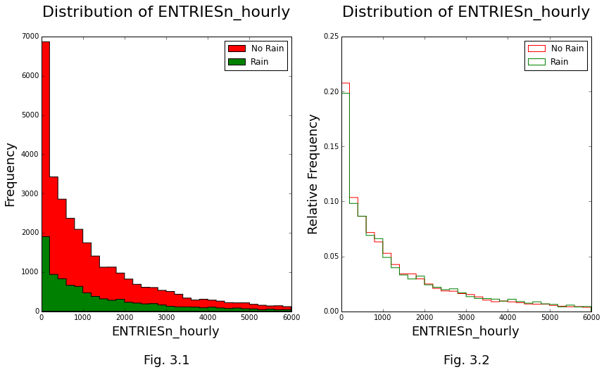

```python
import numpy as np
import matplotlib.pyplot as plt
%matplotlib inline
fontsize = 18
bins = np.linspace(0,6000,31)

fig, axes = plt.subplots(nrows=1, ncols=2, figsize=(14,7))

axes[0].hist(norain.tolist(), bins=bins, color='red', histtype='stepfilled', label='No Rain')
axes[0].hist(rain.tolist(), bins=bins, color='green', histtype='stepfilled', label='Rain')
axes[0].set_title('Distribution of ENTRIESn_hourly\n ', fontsize=fontsize+4)
axes[0].set_xlabel('ENTRIESn_hourly\n\nFig. 3.1', fontsize=fontsize)
axes[0].set_ylabel('Frequency', fontsize=fontsize)
axes[0].legend()

axes[1].hist(norain.tolist(), bins=bins, histtype='step',\
             weights=np.ones_like(norain)/norain.size, color='red', label='No Rain')
axes[1].hist(rain.tolist(), bins=bins, color='green', histtype='step',\
             weights=np.ones_like(rain)/rain.size, label='Rain')
axes[1].set_title('Distribution of ENTRIESn_hourly\n ', fontsize=fontsize+4)
axes[1].set_xlabel('ENTRIESn_hourly\n\nFig. 3.2', fontsize=fontsize)
axes[1].set_ylabel('Relative Frequency', fontsize=fontsize)
axes[1].legend()

plt.show()
```

Fig 3.1 Shows the distribution of entries for both groups of data. The distributions is highly skewed and non-normal. The tendency for both groups looks similar, but because there are more observations in the **norain** group, the histograms have different area.

Fig 3.2 Shows the distribution of entries compared to the total number of observations in each group (relative frequency). With this histogram it is easier to see that both groups have very similar distributions. To be able to see in which ranges each group has lower or higher values, the color fill in the graph is omitted and only the steps are shown.

### 3.2 Boxplots showing the distribution of ENTRIESn_hourly grouped by the variables: weekday, rain, hour, conds (weather conditions), and station.

[figure not shown]

```python
fig, axes = plt.subplots(nrows=2, ncols=2, figsize=(16,14))

weekend, weekday = (tw[tw['weekday']==r]['ENTRIESn_hourly'] for r in (0,1))

axes[0, 0].boxplot([weekday, weekend], showfliers=False, showmeans=True)
axes[0, 0].set_title('Fig. 3.3 Distribution of ENTRIESn_hourly\nby weekday\n ', fontsize=fontsize)
axes[0, 0].set_ylabel('ENTRIESn_hourly', fontsize=fontsize)
axes[0, 0].set_xticklabels(['weekday','weekend'], fontsize=fontsize)

axes[0, 1].boxplot([rain, norain], showfliers=False, showmeans=True)
axes[0, 1].set_title('Fig. 3.4 Distribution of ENTRIESn_hourly\nby rain\n ', fontsize=fontsize)
axes[0, 1].set_xticklabels(['rain','no rain'], fontsize=fontsize)

h0, h4, h8, h12, h16, h20 = (tw[tw['hour']==r]['ENTRIESn_hourly'] for r in (0,4,8,12,16,20))

axes[1, 0].boxplot([h4, h8, h12, h16, h20, h0], showfliers=False, showmeans=True)
axes[1, 0].set_title('Fig. 3.5 Distribution of ENTRIESn_hourly\nby hour\n ', fontsize=fontsize)
axes[1, 0].set_ylabel('ENTRIESn_hourly', fontsize=fontsize)
axes[1, 0].set_xticklabels(['0-4','4-8','8-12','12-16','16-20','20-24'], fontsize=fontsize-2)

by_conds = tw.loc[:,['conds','ENTRIESn_hourly']].groupby('conds')
conds = list(set(tw['conds']))

axes[1, 1].boxplot([by_conds.groups[cond] for cond in conds], showfliers=False, showmeans=True)
axes[1, 1].set_title('Fig. 3.6 Distribution of ENTRIESn_hourly\nby conds (weather conditions)\n ', fontsize=fontsize)
axes[1, 1].set_xticklabels(conds, rotation='vertical', fontsize=fontsize)

fig.subplots_adjust(hspace=0.3)
plt.show()
```

Fig 3.3 Distribution of entries on weekdays and weekends. Weekend ridership is almost half than on weekdays [5]

Fig 3.4 Grouping the data by rain. Another way to see the groups subject of this analysis. The difference in means can be discerned, but in general the distributions seem similar

Fig 3.5 By hour of day, on the other hand, it is easy to discern the differences. Very low ridership up to 8am, higher but similar from 8am to 8pm, and a little less up to 12pm

[figure not shown]

```python
by_station = tw.loc[:,['station','ENTRIESn_hourly']].groupby('station').groups

stations = list(by_station)[130:165]

fig, axes = plt.subplots(nrows=1, ncols=1, figsize=(14,8))

axes.boxplot([by_station[stat] for stat in stations], showfliers=False, showmeans=True)
axes.set_title('Distribution of ENTRIESn_hourly\nby station (some stations only)\n ', fontsize=fontsize+4)
axes.set_xlabel('Fig 3.7', fontsize=fontsize+4)
axes.set_xticklabels(stations, rotation='vertical', fontsize=fontsize)

plt.show()
```

## 4. Conclusions

1. From the analysis and interpretation of this dataset I can conclude that there is a difference in ridership between both groups studied: **rain** and **norain**. The difference is significant and can't be explained only by chance.
2. The Mann-Whitney U test performed on both groups indicate that the probability (p < .001) is so small as to explain the observed differences in ridership by randomness alone.
3. We can conclude with a 95% confidence that one of the groups has a larger mean. When it is rainy, the mean is 2028.2, compared to 1845.5 when it is not raining. There is a difference of 182.7 more entries when it is rainy.
4. The regression analyisis computed shows consistently an increase in ridership when there are rainy conditions.
5. Based on these results we can conclude that more people ride the NYC subway when it rains as compared when it does not rain.

## 5. Reflection

### 5.1 Potential shortcomings

#### *Limitations of the Dataset*

The dataset analyzed contains data only for the month of May 2011. It is during spring, and typically rainy with mild temperatures in NYC. For the analysis to be representative and useful year round, we should have data from at least one whole year.

The dataset contains data for 207 out of the 421 NYC subway stations. Some of the subway stations are located too far from their respective weather station (13 stations are more than 4km away).

The dataset contains very extreme values. They may due to special events like baseball games or concerts, where at the finishig time there could be an extra 10,000 or 20,000 people on the subway, snow, rain or shine. I think these large values should be considered both in the statistical analysis and in the regression analysis.

About the **hour** variable, the hours chosen when the transformation of the original data was made are: [0, 4, 8, 12, 16, 20], each corresponding to the ending hour of a 4 hour period. My concern is about the first number: 0 which has the observations from 20:00 the day before, to 0:00 today. I think the correct values should be [4, 8, 12, 16, 20, 24], all of the same day. In Fig. 3.5 I had to put hour 0 at the end of the graph for it to make sense.

#### *Limitations of the Analysis*

The presence of extreme values in this dataset is very important and carry valuable information that should be taken into consideration. They are not "bad points" but data with information that should be investigated carefully.

In this analysis, however they produce a bias in the result. Not so much in the Mann-Whitney test because the method assigns a rank to each value, regardless of the high difference in value between them.